# DATA 607 Project 2

Evan McLaughlin

3/13/2021

## Dataset #1 - Background

The assignment tasks students with selecting a messy dataset posted by a peer and cleaning it for analysis as set forth in the peer’s post and beyond. For our dataset, we selected Maria’s dataset from UNICEF, and I undertook her question regarding newborn, infant, and young child nutrition. Prior to importing the data, I executed some operations on the dataset to facilitate importing and analysis including: - change all “-” to “NAs” - change percentages to decimals - strip out footnotes from the bottom - drop tabs that are anciliary to the analysis at hand so as to be able to save the data as .csv - drop extraneous columns and rows

## Import and Clean Data

```r
nutrition = read.csv("https://raw.githubusercontent.com/evanmclaughlin/ECM607/master/UNICEF_Table-7-Nutrition-EN.csv")


head(nutrition)
```

```
##       Country Low.birthweight Unweighed.at.birth
## 1 Afghanistan              NA          0.8626837
## 2     Albania      0.04587830          0.1316733
## 3     Algeria      0.07252492          0.1142705
## 4     Andorra      0.07445406          0.1430000
## 5      Angola      0.15256593          0.4480227
## 6    Anguilla              NA                 NA
##   Early.initiation.of.breastfeeding Exclusive.breastfeeding...6.months.
## 1                         0.6280000                               0.575
## 2                         0.5652210                          0.36538513
## 3                         0.3571079                          0.25391212
## 4                                NA                                <NA>
## 5                         0.4831644                          0.37381931
## 6                                NA                                <NA>
##   Introduction.to.solid..semi.solid.or.soft.foods Breastfeeding...All
```

[output cut: 41 more lines]

## Extract appropriate data for subsetting

```r
#start with re-labeling countries and the first variables we're interested in analyzing
names(nutrition)[1] <- "countries"
names(nutrition)[2] <- "low_birthweight"
names(nutrition)[4] <- "early_breast"
names(nutrition)[5] <- "exclusive_breast"
names(nutrition)[7] <- "breast_all"
names(nutrition)[13] <- "zero_veg"
names(nutrition)[14] <- "region"

#head(nutrition)

#next, extract the renamed columns for a subset
nut_ext <- nutrition %>% dplyr::select(1, 2, 4, 5, 7, 13, 14)
head(nut_ext)
```

```
##     countries low_birthweight early_breast exclusive_breast breast_all
## 1 Afghanistan              NA    0.6280000            0.575  0.7380154
## 2     Albania      0.04587830    0.5652210       0.36538513  0.4320668
## 3     Algeria      0.07252492    0.3571079       0.25391212  0.3554286
## 4     Andorra      0.07445406           NA             <NA>         NA
## 5      Angola      0.15256593    0.4831644       0.37381931  0.6656777
## 6    Anguilla              NA           NA             <NA>         NA
##    zero_veg            region
## 1 0.5857060
## 2 0.2573565
## 3        NA
## 4        NA
## 5 0.3635851
## 6        NA LATAM - Caribbean
```

## Now that we have our data extracted, we can try to make some observations from a filtered dataset

```r
## let's filter the dataset for our desired LATAM - Caribbean subest
la_nut <- nut_ext %>% filter(region == 'LATAM - Caribbean')
la_nut
```

```
##                             countries low_birthweight early_breast
## 1                            Anguilla              NA           NA
## 2                 Antigua and Barbuda      0.09054119           NA
## 3                           Argentina      0.07346758    0.5274035
## 4                             Bahamas      0.13135983           NA
## 5                            Barbados              NA    0.4029047
## 6                              Belize      0.08598801    0.6825412
## 7    Bolivia (Plurinational State of)      0.07222335    0.5500000
## 8                              Brazil      0.08384270    0.4290000
## 9              British Virgin Islands              NA           NA
## 10                              Chile      0.06246671           NA
## 11                           Colombia      0.09955593    0.7200000
## 12                         Costa Rica      0.07477285    0.5962632
## 13                               Cuba      0.05263557    0.4787731
## 14                           Dominica              NA           NA
```

[output cut: 59 more lines]

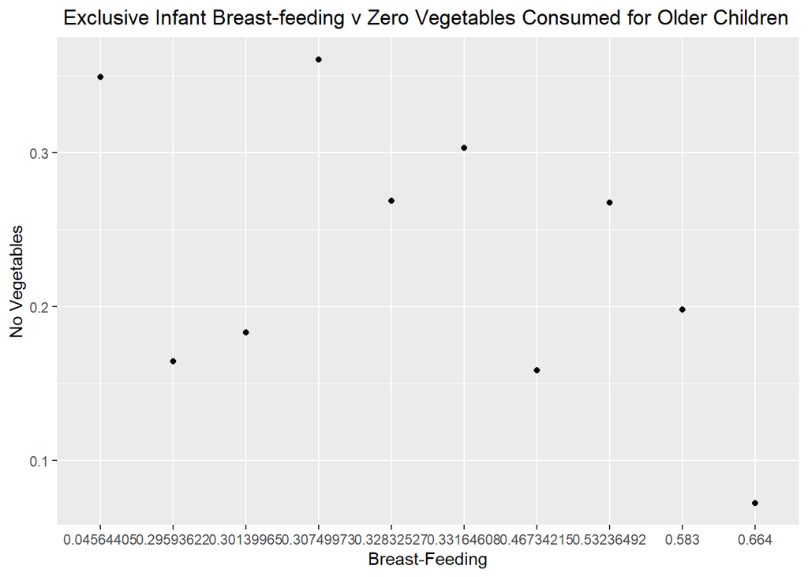

```r
## We can start by trying to discover some relationship between low birthweight, likelihood of breastfeeding exclusively as an infant, and nutritional habits as the child gets older in the form of the likelihood of zero vegetables being consumed

# Let's strip out the NAs first

la_nut <-na.omit(la_nut)

qplot(x=exclusive_breast, y=zero_veg, data=la_nut, main=" Exclusive Infant Breast-feeding v Zero Vegetables Consumed for Older Children ", xlab="Breast-Feeding", ylab="No Vegetables")
```

## There does not appear to be much of a graphical relationship among these countries between the likelihood of breast-feeding infants exclusively and the likelihood that young children in those countries consume no vegetables in a given day. But we can try to derive a relationship mathematically.

```r
nut_score <- lm(`exclusive_breast` ~ `zero_veg`, data = la_nut)

nut_score
```

```
##
## Call:
## lm(formula = exclusive_breast ~ zero_veg, data = la_nut)
##
## Coefficients:
## (Intercept)     zero_veg
##       0.681       -1.269
```

## Dataset 2 - Background

The assignment tasks students with selecting a messy dataset posted by a peer and cleaning it for analysis as set forth in the peer’s post and beyond. For our dataset, we selected Maria’s dataset from UNICEF, and I undertook a new analysis on literacy in Latin America. Prior to importing the data, I executed some operations on the dataset to facilitate importing and analysis including: - change all “-” to “NAs” - change percentages to decimals - strip out footnotes from the bottom - drop tabs that are ancillary to the analysis at hand so as to be able to save the data as .csv - drop extraneous columns and rows - concatenate the gender with each of the column names

## Import and Clean Data

```r
education = read.csv("https://raw.githubusercontent.com/evanmclaughlin/ECM607/master/Table-10-Education-EN.csv")

head(education)
```

```
##             X Completion.Primary.education.male
## 1 Afghanistan                             0.67
## 2     Albania                             0.91
## 3     Algeria                             0.93
## 4     Andorra                               NA
## 5      Angola                             0.53
## 6    Anguilla                               NA
##   Completion.Primary.education.female Completion.Lower.secondary.education.male
## 1                               0.40                                      0.49
## 2                               0.93                                      0.97
## 3                               0.94                                      0.57
## 4                                 NA                                        NA
## 5                               0.49                                      0.41
## 6                                 NA                                        NA
##   Completion.Lower.secondary.education.female
```

[output cut: 69 more lines]

## Extract appropriate data for subsetting

```r
# Let's go ahead and quickly filter for the LATAM and Caribbean nations that we are interested in comparing, as well as the literacy variables we're interested in exploring

names(education)[16] <- "region"
names(education)[1] <- "country"
names(education)[15] <- "youth_literacy_female"
names(education)[14] <- "youth_literacy_male"
education$youth_literacy_male <- as.numeric(as.character(education$youth_literacy_male))
education$youth_literacy_female <- as.numeric(as.character(education$youth_literacy_female))
education <- education %>% filter(region == 'LATAM-Caribbean')

#next, let's extract the renamed columns for a subset
la_edu <- education %>% dplyr::select(1, 14, 15)
la_lit <- la_edu %>% filter(!is.na(la_edu$youth_literacy_female))
```

## Now that we have our data extracted, we can try to make some observations from a filtered dataset

```r
## We can start by trying to look at any differences between Latin American females and males in terms of youth literacy

m_male <- mean(la_lit$youth_literacy_male)
m_fem <- mean(la_lit$youth_literacy_female)

m_male
```

```
## [1] 0.9820833
```

```r
m_fem
```

```
## [1] 0.9858333
```

```r
# female literacy across LATAM countries is slightly higher than male literacy rate, so we'll sort by descending female literacy rate to get a good look at the region
la_lit <- la_lit %>%
  arrange(desc(youth_literacy_female))
```

```r
library(reactable)
reactable(la_lit)
```

| country | youth_literacy_male | youth_literacy_female |
| --- | --- | --- |
| Argentina | 0.99 | 1 |
| Barbados | 1 | 1 |
| Cuba | 1 | 1 |
| Grenada | 0.99 | 1 |
| Trinidad and Tobago | 1 | 1 |
| Bolivia (Plurinational State of) | 0.99 | 0.99 |
| Brazil | 0.99 | 0.99 |
| Chile | 0.99 | 0.99 |
| Colombia | 0.98 | 0.99 |
| Costa Rica | 0.99 | 0.99 |

[output cut: 14 more lines]

## All in all, the youth literacy rate is exceptionally high across the Latin America and Caribbean region, with there not being much variance between males and females in any of the countries measured.

## Dataset 3 - Background

Let’s talk about squirrels. Joseph’s post was about how squirrels in New York City live and the possible forecasts that can be made for 2019 and beyond from this 2018 data.

```r
squirrels = read.csv("https://raw.githubusercontent.com/evanmclaughlin/ECM607/master/squirrels.csv")

head(squirrels)
```

```
##           X        Y Unique.Squirrel.ID Hectare Shift     Date
## 1 -73.95613 40.79408     37F-PM-1014-03     37F    PM 10142018
## 2 -73.96886 40.78378     21B-AM-1019-04     21B    AM 10192018
## 3 -73.97428 40.77553     11B-PM-1014-08     11B    PM 10142018
## 4 -73.95964 40.79031     32E-PM-1017-14     32E    PM 10172018
## 5 -73.97027 40.77621     13E-AM-1017-05     13E    AM 10172018
## 6 -73.96836 40.77259     11H-AM-1010-03     11H    AM 10102018
##   Hectare.Squirrel.Number   Age Primary.Fur.Color Highlight.Fur.Color
## 1                       3
## 2                       4
## 3                       8                    Gray
## 4                      14 Adult              Gray
## 5                       5 Adult              Gray            Cinnamon
## 6                       3 Adult          Cinnamon               White
##   Combination.of.Primary.and.Highlight.Color
```

[output cut: 41 more lines]

```r
names(squirrels)[1] <- "lat"
names(squirrels)[2] <- "long"
names(squirrels)[6] <- "date"
names(squirrels)[16] <- "running"
names(squirrels)[17] <- "chasing"
names(squirrels)[18] <- "climbing"
names(squirrels)[19] <- "eating"
names(squirrels)[20] <- "foraging"
names(squirrels)[9] <- "color"

s_data <- squirrels %>% dplyr::select(1, 2, 6, 9, 16, 17, 18, 19, 20)

head(s_data)
```

```
##         lat     long     date    color running chasing climbing eating foraging
## 1 -73.95613 40.79408 10142018            FALSE   FALSE    FALSE  FALSE    FALSE
## 2 -73.96886 40.78378 10192018            FALSE   FALSE    FALSE  FALSE    FALSE
## 3 -73.97428 40.77553 10142018     Gray   FALSE    TRUE    FALSE  FALSE    FALSE
## 4 -73.95964 40.79031 10172018     Gray   FALSE   FALSE    FALSE   TRUE     TRUE
## 5 -73.97027 40.77621 10172018     Gray   FALSE   FALSE    FALSE  FALSE     TRUE
## 6 -73.96836 40.77259 10102018 Cinnamon   FALSE   FALSE    FALSE  FALSE     TRUE
```

```r
# we can visualize all of this quickly with a simple bar graph after we use spread to organize the data

# create new dataframe

squirrels_df <- gather(s_data, action, T_F, 5:9)
#squirrels_df

## now let's filter the new dataframe for squirrels that aren't clearly lazy

action_squirrels <- squirrels_df %>% filter(T_F == 'TRUE')
#action_squirrels

action_squirrels$color <- sub("^$", "Other", action_squirrels$color)
head(action_squirrels)
```

```
##         lat     long     date    color  action  T_F
## 1 -73.96400 40.78203 10142018     Gray running TRUE
## 2 -73.97686 40.77028 10102018 Cinnamon running TRUE
## 3 -73.97038 40.77875 10182018     Gray running TRUE
## 4 -73.96711 40.77849 10072018     Gray running TRUE
## 5 -73.95874 40.79085 10082018     Gray running TRUE
## 6 -73.96929 40.77695 10132018     Gray running TRUE
```

```r
# now let's go ahead and look at what these active squirrels are doing most of the time

library("rcartocolor")
```

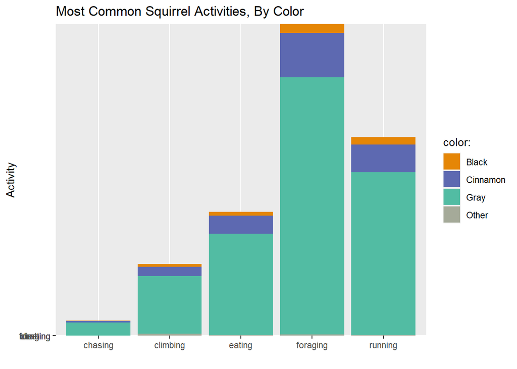

```r
ggplot(action_squirrels, aes(x = action, y = action, fill = reorder(color, action))) +
  geom_col() +
  labs(title="Most Common Squirrel Activities, By Color") +
  ylab('Activity') +
  xlab('') +
  scale_fill_carto_d(name = "color: ", palette = "Vivid")
```

Are squirrels who aren’t gray more likely to be lazy good-for-nothings? Do Cinnamon and Black squirrels more easily pass undetected by human eyes? Or are there just more gray squirrels than any other kind? This is an easy test.

```r
# first let's see the percentage of gray squirrels in the action table
squ_table <- table(action_squirrels$color)
squ_table
```

```
##
##    Black Cinnamon     Gray    Other
##      125      529     3170       38
```

```r
gray_pct_act <- 3170 / nrow(action_squirrels)
gray_pct_act
```

```
## [1] 0.8208182
```

```r
# now let's look at the numbers for the full dataset
squ_table_full <- table(squirrels_df$color)
squ_table_full
```

```
##
##             Black Cinnamon     Gray
##      275      515     1960    12365
```

```r
gray_pct_full <- 12365 / nrow(squirrels_df)
gray_pct_full
```

```
## [1] 0.8180615
```

What an enormous relief. The percentage of Gray squirrels in the active dataset is roughly the same as in the full dataset. The last thing we need is an elitist population of Black and Cinnamon squirrels taking advantage of an industrious class of Gray squirrels.